# Aufgaben_teil1_A3-A4

2024-05-19

## A-3

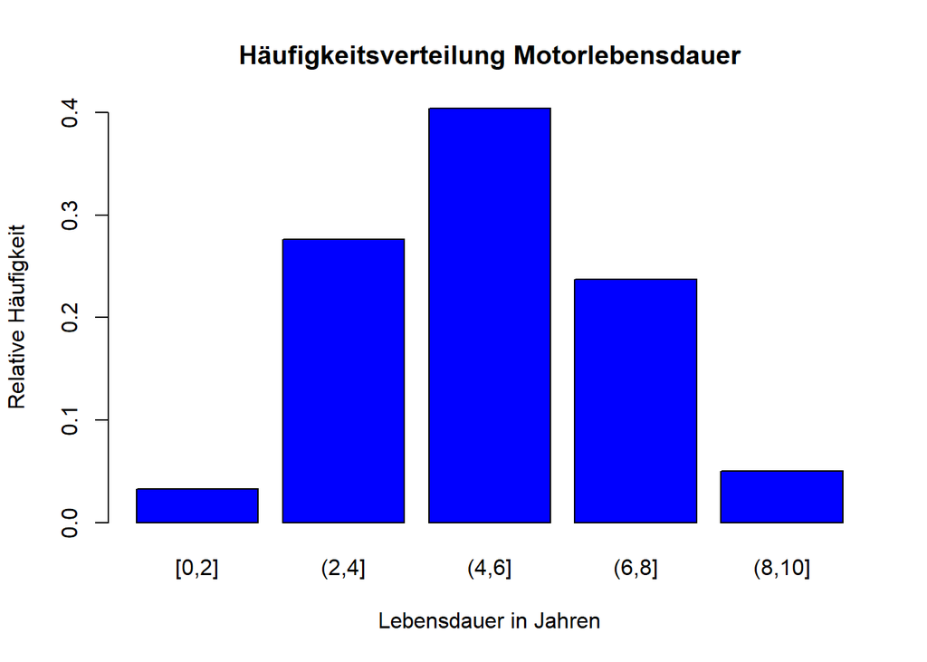

```r
lifetime_motor_count <- c(33, 276, 404, 237, 50)
lifetime_motor_count.rel <- lifetime_motor_count/sum(lifetime_motor_count)
lifetime_years <- c("[0,2]", "(2,4]", "(4,6]", "(6,8]", "(8,10]")

barplot(lifetime_motor_count.rel ,
        names.arg = lifetime_years,
        col = "blue",
        xlab = "Lebensdauer in Jahren",
        ylab = "Relative Häufigkeit",
        main = "Häufigkeitsverteilung Motorlebensdauer"
        )
```

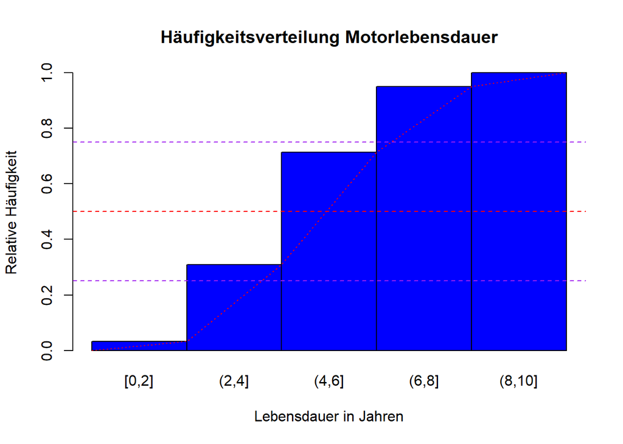

```r
lifetime_motor_count.cum <- cumsum(lifetime_motor_count.rel)

# Bar plot of cumulative relative frequencies
barplot_positions <- barplot(lifetime_motor_count.cum,  # Positions holds the mid values.
        names.arg = lifetime_years,
        col = "blue",
        xlab = "Lebensdauer in Jahren",
        ylab = "Relative Häufigkeit",
        main = "Häufigkeitsverteilung Motorlebensdauer",
        space = 0
)

# Plot the cumulative distribution line

line_positions_x <- c(0, barplot_positions + (barplot_positions[2] - barplot_positions[1]) /2) # Create X coordinates. Assuming they are evenly spread
par(new = TRUE)
lines(x = line_positions_x,
      y = c(0, lifetime_motor_count.cum), # We are starting at coord x=0, y=0
      lty = 3,
      col = "red")

abline(0.25, 0, lty = "dashed", col = "purple")
abline(0.5, 0, lty = "dashed", col = "red")
abline(0.75, 0, lty = "dashed", col = "purple")
```

## zu b) Das arithmetische Mittel ist bei relativer Häufigkeit = 0,5. Daher schätze ich es auf 4,8 Jahre. Der Median ist bei dieser Darstellung jender Balken, der bei Häufigkeit 0.5 geschnitten wird. Er ist daher im Intervall von (4,6] Jahren.

## zu c)

```r
more_than_six_years <- sum(lifetime_motor_count[4:5])
cat("Mehr als 6 Jahre Laufzeit hatten", more_than_six_years, "Motoren.")
```

```
## Mehr als 6 Jahre Laufzeit hatten 287 Motoren.
```

## zu d)

```r
mode_pos <- lifetime_motor_count == max(lifetime_motor_count)
mode <- lifetime_years[mode_pos]
cat("Modus ist der Intervall", mode)
```

```
## Modus ist der Intervall (4,6]
```

```r
mids <- seq(1,9,2)
mean_val <- mean(sum(lifetime_motor_count * mids) / sum(lifetime_motor_count))
cat("Arithemtisches Mittel ist", mean_val)
```

```
## Arithemtisches Mittel ist 4.99
```

Aus den Daten ist ersichtlich, dass der Median beim Intervall (4,6] liegt. Min ist [0, 2] Jahre Max ist (8, 10] Jahre Spannweite sind 10 Jahre

```r
# Generate list of given values
lifetime_list <- c()
for (i in 1:length(mids)){
  lifetime_list <- c(lifetime_list, rep(mids[i], lifetime_motor_count[i]))
}

standard_dev <- sd(lifetime_list)
cat("Standardabweichung ist", standard_dev)
```

```
## Standardabweichung ist 1.83937
```

```r
mean_abs_dev <- sum(abs(lifetime_list - mean_val)) / sum(lifetime_motor_count)
cat("Mittlere Absolute Abweichung", mean_abs_dev)
```

```
## Mittlere Absolute Abweichung 1.36182
```

Quantile:

```r
quantile(lifetime_list)
```

```
##   0%  25%  50%  75% 100%
##    1    3    5    7    9
```

# A-4

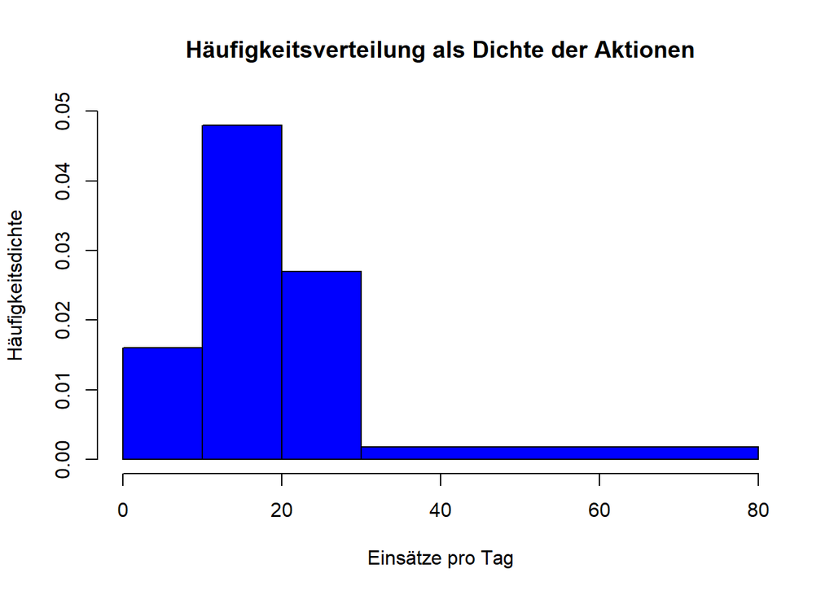

```r
action_count <- c(16, 48, 27, 9)
action_count.rel <- action_count/sum(action_count)
actions_day <- c("[0,10]", "(10,20]", "(20,30]", "(30,80]")
mids <- c(5,15,25,55)
breaks_actions <- c(0,10,20,30,80)

# Generate list of given values
data_list <- c()
for (i in 1:length(mids)){
  data_list <- c(data_list, rep(mids[i], action_count[i]))
}

hist_actions <- hist(data_list,
     breaks=breaks_actions,
     col = "blue",
     xlab = "Einsätze pro Tag",
     ylab = "Häufigkeitsdichte",
     main = "Häufigkeitsverteilung als Dichte der Aktionen",
     ylim = c(0,0.05),
     freq = FALSE
     )
```

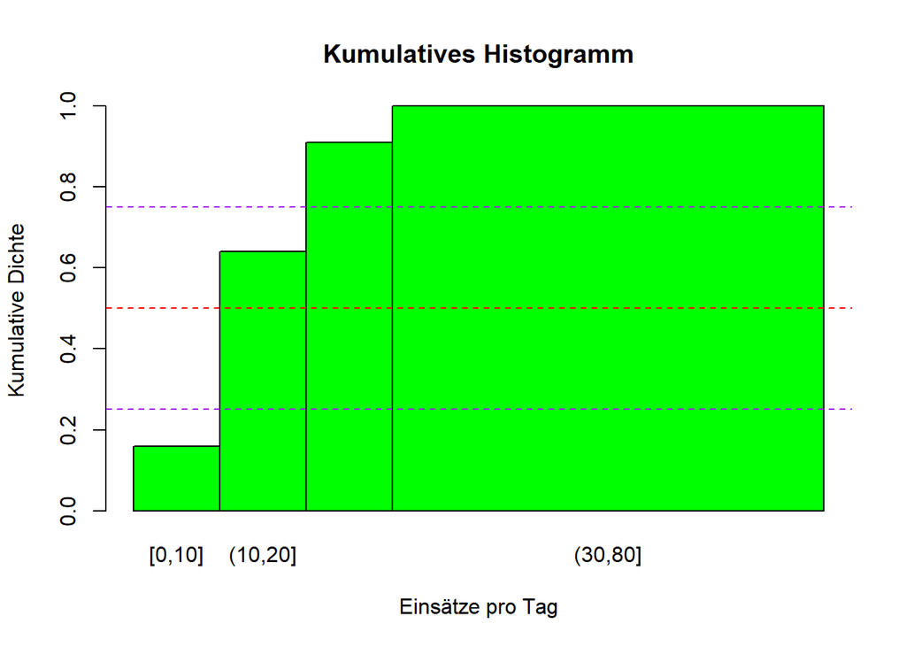

```r
density_vec_cum <- cumsum(hist_actions$density * diff(hist_actions$breaks))

barplot(
  density_vec_cum,
  width = diff(hist_actions$breaks),
  names.arg = actions_day,
  space = 0,
  xlab = "Einsätze pro Tag",
  ylab = "Kumulative Dichte",
  main = "Kumulatives Histogramm",
  col = "green"
)


abline(0.25, 0, lty = "dashed", col = "purple")
abline(0.5, 0, lty = "dashed", col = "red")
abline(0.75, 0, lty = "dashed", col = "purple")
```

```r
more_than_20 <- sum(action_count[3:4])
cat("Mehr als 20 Einsätze an", more_than_20, "Tagen")
```

```
## Mehr als 20 Einsätze an 36 Tagen
```

Modus: Interval (10,20]

```r
quantile(data_list)
```

```
##   0%  25%  50%  75% 100%
##    5   15   15   25   55
```

```r
mean_val <- mean(data_list)
cat("Mittelwert:" ,mean_val)
```

```
## Mittelwert: 19.7
```

Minimum: 0 Einsätze Maximum: 80 Einsätze Spannweite: 80 Einsätze

```r
cat("Standardabweichung:", sd(data_list))
```

```
## Standardabweichung: 12.90642
```

```r
mean_abs_dev <- sum(abs(data_list - mean_val)) / sum(data_list)
cat("Mittlere Absolute Abweichung", mean_abs_dev)
```

```
## Mittlere Absolute Abweichung 0.4678173
```

Es ist hier problematisch die Maße zu berechnen, da die Urliste bereits aus Intervallen besteht. Außerdem ist der Intervall (30,80] sehr groß gewählt. In meiner Berechnung bin ich vom Mittelwert 55 ausgegangen. Es wäre hier auch möglich, linear zu Interpolieren um auf ein Art Urliste zu kommen. Hierfür müssten Werte im Intervall gewählte werden, sodass die gleiche Anzahl herauskommt. Es muss dabei aber auf ganze Zahlen gerundet werden, da es keine reelwertigen Einsätze pro Tag gibt. Darauf wurde hier aber verzichtet.